# pj2

## Traffic Accidents and Vehicle Involvement Between 2010 and 2011 in UK

team members: Muxue Liu, muxue; Yijia Wang, yijiaw; Qirong Wang,qirong

#### Descriptive Statistics

```python
# Load libraries
import pandas as pd
import seaborn as sns
import matplotlib.pyplot as plt
```

```python
# Load the data
vehicle = pd.read_csv('Vehicle_Information.csv', encoding='ISO-8859-1')

vehicle.head(3)
```

|  | Accident_Index | Age_Band_of_Driver | Age_of_Vehicle | Driver_Home_Area_Type | Driver_IMD_Decile | Engine_Capacity_.CC. | Hit_Object_in_Carriageway | Hit_Object_off_Carriageway | Journey_Purpose_of_Driver | Junction_Location | ... | Skidding_and_Overturning | Towing_and_Articulation | Vehicle_Leaving_Carriageway | Vehicle_Location.Restricted_Lane | Vehicle_Manoeuvre | Vehicle_Reference | Vehicle_Type | Was_Vehicle_Left_Hand_Drive | X1st_Point_of_Impact | Year |
| --- | --- | --- | --- | --- | --- | --- | --- | --- | --- | --- | --- | --- | --- | --- | --- | --- | --- | --- | --- | --- | --- |
| 0 | 200401BS00001 | 26 - 35 | 3.0 | Urban area | 4.0 | 1588.0 | NaN | NaN | Data missing or out of range | Data missing or out of range | ... | NaN | No tow/articulation | Did not leave carriageway | 0.0 | Going ahead other | 2 | 109 | Data missing or out of range | Front | 2004 |
| 1 | 200401BS00002 | 26 - 35 | NaN | Urban area | 3.0 | NaN | NaN | NaN | Data missing or out of range | Data missing or out of range | ... | NaN | No tow/articulation | Did not leave carriageway | 0.0 | Going ahead other | 1 | 109 | Data missing or out of range | Front | 2004 |
| 2 | 200401BS00003 | 26 - 35 | 4.0 | Data missing or out of range | NaN | 998.0 | NaN | NaN | Data missing or out of range | Data missing or out of range | ... | NaN | No tow/articulation | Did not leave carriageway | 0.0 | Turning right | 1 | 109 | Data missing or out of range | Front | 2004 |

3 rows × 24 columns

```python
vehicle[vehicle['Year']==2011].reset_index(drop=True).head(3)
```

|  | Accident_Index | Age_Band_of_Driver | Age_of_Vehicle | Driver_Home_Area_Type | Driver_IMD_Decile | Engine_Capacity_.CC. | Hit_Object_in_Carriageway | Hit_Object_off_Carriageway | Journey_Purpose_of_Driver | Junction_Location | ... | Skidding_and_Overturning | Towing_and_Articulation | Vehicle_Leaving_Carriageway | Vehicle_Location.Restricted_Lane | Vehicle_Manoeuvre | Vehicle_Reference | Vehicle_Type | Was_Vehicle_Left_Hand_Drive | X1st_Point_of_Impact | Year |
| --- | --- | --- | --- | --- | --- | --- | --- | --- | --- | --- | --- | --- | --- | --- | --- | --- | --- | --- | --- | --- | --- |
| 0 | 201101BS70001 | Data missing or out of range | NaN | Data missing or out of range | NaN | NaN | NaN | NaN | Not known | Mid Junction - on roundabout or on main road | ... | NaN | No tow/articulation | Did not leave carriageway | 0.0 | Going ahead other | 1 | Car | No | Front | 2011 |
| 1 | 201101BS70002 | 26 - 35 | 4.0 | Urban area | 5.0 | 125.0 | NaN | NaN | Not known | Mid Junction - on roundabout or on main road | ... | NaN | No tow/articulation | Did not leave carriageway | 0.0 | Going ahead other | 2 | Motorcycle 125cc and under | No | Nearside | 2011 |
| 2 | 201101BS70003 | 46 - 55 | 9.0 | Urban area | 2.0 | 7300.0 | NaN | NaN | Journey as part of work | Not at or within 20 metres of junction | ... | NaN | No tow/articulation | Did not leave carriageway | 0.0 | Slowing or stopping | 1 | Bus or coach (17 or more pass seats) | No | Nearside | 2011 |

3 rows × 24 columns

```python
accident = pd.read_csv('Accident_Information.csv', encoding='ISO-8859-1')
accident.head(3)
```

|  | Accident_Index | 1st_Road_Class | 1st_Road_Number | 2nd_Road_Class | 2nd_Road_Number | Accident_Severity | Carriageway_Hazards | Date | Day_of_Week | Did_Police_Officer_Attend_Scene_of_Accident | ... | Police_Force | Road_Surface_Conditions | Road_Type | Special_Conditions_at_Site | Speed_limit | Time | Urban_or_Rural_Area | Weather_Conditions | Year | InScotland |
| --- | --- | --- | --- | --- | --- | --- | --- | --- | --- | --- | --- | --- | --- | --- | --- | --- | --- | --- | --- | --- | --- |
| 0 | 200501BS00001 | A | 3218.0 | NaN | 0.0 | Serious | NaN | 2005-01-04 | Tuesday | 1.0 | ... | Metropolitan Police | Wet or damp | Single carriageway | NaN | 30.0 | 17:42 | Urban | Raining no high winds | 2005 | No |
| 1 | 200501BS00002 | B | 450.0 | C | 0.0 | Slight | NaN | 2005-01-05 | Wednesday | 1.0 | ... | Metropolitan Police | Dry | Dual carriageway | NaN | 30.0 | 17:36 | Urban | Fine no high winds | 2005 | No |
| 2 | 200501BS00003 | C | 0.0 | NaN | 0.0 | Slight | NaN | 2005-01-06 | Thursday | 1.0 | ... | Metropolitan Police | Dry | Single carriageway | NaN | 30.0 | 00:15 | Urban | Fine no high winds | 2005 | No |

3 rows × 34 columns

```python
accident[accident['Year']==2011].reset_index(drop=True).head(3)
```

|  | Accident_Index | 1st_Road_Class | 1st_Road_Number | 2nd_Road_Class | 2nd_Road_Number | Accident_Severity | Carriageway_Hazards | Date | Day_of_Week | Did_Police_Officer_Attend_Scene_of_Accident | ... | Police_Force | Road_Surface_Conditions | Road_Type | Special_Conditions_at_Site | Speed_limit | Time | Urban_or_Rural_Area | Weather_Conditions | Year | InScotland |
| --- | --- | --- | --- | --- | --- | --- | --- | --- | --- | --- | --- | --- | --- | --- | --- | --- | --- | --- | --- | --- | --- |
| 0 | 201101BS70001 | C | 0.0 | Unclassified | 0.0 | Slight | NaN | 2011-01-13 | Thursday | 1.0 | ... | Metropolitan Police | Wet or damp | Single carriageway | NaN | 30.0 | 16:54 | Urban | Raining no high winds | 2011 | No |
| 1 | 201101BS70002 | C | 0.0 | Unclassified | 0.0 | Serious | NaN | 2011-01-11 | Tuesday | 1.0 | ... | Metropolitan Police | Wet or damp | Single carriageway | NaN | 30.0 | 19:45 | Urban | Fine no high winds | 2011 | No |
| 2 | 201101BS70003 | B | 304.0 | NaN | 0.0 | Slight | NaN | 2011-01-19 | Wednesday | 1.0 | ... | Metropolitan Police | Dry | Single carriageway | NaN | 30.0 | 17:30 | Urban | Fine no high winds | 2011 | No |

3 rows × 34 columns

```python
# Merging the datasets on 'Accident_Index'
combined_data = pd.merge(accident, vehicle, on='Accident_Index')
combined_data
```

|  | Accident_Index | 1st_Road_Class | 1st_Road_Number | 2nd_Road_Class | 2nd_Road_Number | Accident_Severity | Carriageway_Hazards | Date | Day_of_Week | Did_Police_Officer_Attend_Scene_of_Accident | ... | Skidding_and_Overturning | Towing_and_Articulation | Vehicle_Leaving_Carriageway | Vehicle_Location.Restricted_Lane | Vehicle_Manoeuvre | Vehicle_Reference | Vehicle_Type | Was_Vehicle_Left_Hand_Drive | X1st_Point_of_Impact | Year_y |
| --- | --- | --- | --- | --- | --- | --- | --- | --- | --- | --- | --- | --- | --- | --- | --- | --- | --- | --- | --- | --- | --- |
| 0 | 200501BS00002 | B | 450.0 | C | 0.0 | Slight | NaN | 2005-01-05 | Wednesday | 1.0 | ... | NaN | No tow/articulation | Did not leave carriageway | 0.0 | Slowing or stopping | 1 | Bus or coach (17 or more pass seats) | No | Nearside | 2005 |
| 1 | 200501BS00003 | C | 0.0 | NaN | 0.0 | Slight | NaN | 2005-01-06 | Thursday | 1.0 | ... | NaN | No tow/articulation | Did not leave carriageway | 0.0 | Going ahead right-hand bend | 1 | Bus or coach (17 or more pass seats) | No | Nearside | 2005 |
| 2 | 200501BS00004 | A | 3220.0 | NaN | 0.0 | Slight | NaN | 2005-01-07 | Friday | 1.0 | ... | NaN | No tow/articulation | Did not leave carriageway | 0.0 | Going ahead other | 1 | Car | No | Front | 2005 |
| 3 | 200501BS00005 | Unclassified | 0.0 | NaN | 0.0 | Slight | NaN | 2005-01-10 | Monday | 1.0 | ... | Skidded | No tow/articulation | Did not leave carriageway | 0.0 | Going ahead other | 1 | Motorcycle 125cc and under | No | Front | 2005 |
| 4 | 200501BS00006 | Unclassified | 0.0 | NaN | 0.0 | Slight | NaN | 2005-01-11 | Tuesday | 1.0 | ... | NaN | No tow/articulation | Did not leave carriageway | 0.0 | Moving off | 1 | Car | No | Did not impact | 2005 |
| ... | ... | ... | ... | ... | ... | ... | ... | ... | ... | ... | ... | ... | ... | ... | ... | ... | ... | ... | ... | ... | ... |
| 2058403 | 2016984131116 | B | 7020.0 | C | 49.0 | Slight | NaN | 2016-11-01 | Tuesday | 1.0 | ... | NaN | No tow/articulation | Did not leave carriageway | 0.0 | Going ahead other | 1 | Car | No | Front | 2016 |
| 2058404 | 2016984131116 | B | 7020.0 | C | 49.0 | Slight | NaN | 2016-11-01 | Tuesday | 1.0 | ... | NaN | No tow/articulation | Offside | 0.0 | Going ahead other | 2 | Car | No | Front | 2016 |
| 2058405 | 2016984131216 | A(M) | 74.0 | NaN | 0.0 | Slight | NaN | 2016-10-27 | Thursday | 1.0 | ... | NaN | No tow/articulation | Offside on to central reservation | 0.0 | Going ahead other | 1 | Goods 7.5 tonnes mgw and over | No | Offside | 2016 |
| 2058406 | 2016984131316 | B | 724.0 | NaN | 0.0 | Slight | NaN | 2016-10-29 | Saturday | 1.0 | ... | Skidded | No tow/articulation | Offside | 0.0 | Going ahead other | 1 | Car | No | Front | 2016 |
| 2058407 | 2016984133416 | A(M) | 74.0 | NaN | 0.0 | Slight | NaN | 2016-12-25 | Sunday | 1.0 | ... | Skidded and overturned | No tow/articulation | Nearside | 0.0 | Going ahead other | 1 | Car | No | Nearside | 2016 |

2058408 rows × 57 columns

```python
data_2010_2011 = combined_data[(combined_data['Year_y'] == 2010) | (combined_data['Year_y'] == 2011)]
data_2010_2011.head()
```

|  | Accident_Index | 1st_Road_Class | 1st_Road_Number | 2nd_Road_Class | 2nd_Road_Number | Accident_Severity | Carriageway_Hazards | Date | Day_of_Week | Did_Police_Officer_Attend_Scene_of_Accident | ... | Skidding_and_Overturning | Towing_and_Articulation | Vehicle_Leaving_Carriageway | Vehicle_Location.Restricted_Lane | Vehicle_Manoeuvre | Vehicle_Reference | Vehicle_Type | Was_Vehicle_Left_Hand_Drive | X1st_Point_of_Impact | Year_y |
| --- | --- | --- | --- | --- | --- | --- | --- | --- | --- | --- | --- | --- | --- | --- | --- | --- | --- | --- | --- | --- | --- |
| 659243 | 201001BS70003 | B | 302.0 | Unclassified | 0.0 | Slight | NaN | 2010-01-11 | Monday | 1.0 | ... | NaN | No tow/articulation | Did not leave carriageway | 0.0 | Turning right | 1 | Van / Goods 3.5 tonnes mgw or under | No | Front | 2010 |
| 659244 | 201001BS70004 | A | 402.0 | A | 4204.0 | Slight | NaN | 2010-01-11 | Monday | 1.0 | ... | NaN | No tow/articulation | Did not leave carriageway | 0.0 | Going ahead other | 1 | Car | No | Front | 2010 |
| 659245 | 201001BS70006 | A | 402.0 | B | 450.0 | Slight | NaN | 2010-01-12 | Tuesday | 1.0 | ... | NaN | No tow/articulation | Did not leave carriageway | 0.0 | Turning left | 1 | Goods over 3.5t. and under 7.5t | No | Nearside | 2010 |
| 659246 | 201001BS70007 | Unclassified | 0.0 | Unclassified | 0.0 | Slight | NaN | 2010-01-02 | Saturday | 1.0 | ... | NaN | No tow/articulation | Did not leave carriageway | 0.0 | Going ahead right-hand bend | 1 | Car | No | Nearside | 2010 |
| 659247 | 201001BS70007 | Unclassified | 0.0 | Unclassified | 0.0 | Slight | NaN | 2010-01-02 | Saturday | 1.0 | ... | NaN | No tow/articulation | Did not leave carriageway | 0.0 | Going ahead other | 2 | Car | No | Front | 2010 |

5 rows × 57 columns

```python
# Check how many missing values are there in each column
data_2010_2011.isnull().sum()
```

```
Accident_Index                                      0
1st_Road_Class                                      0
1st_Road_Number                                     0
2nd_Road_Class                                 143820
2nd_Road_Number                                  4448
Accident_Severity                                   0
Carriageway_Hazards                            354838
Date                                                0
Day_of_Week                                         0
Did_Police_Officer_Attend_Scene_of_Accident         0
Junction_Control                                    0
Junction_Detail                                     0
Latitude                                            0
Light_Conditions                                    0
Local_Authority_(District)                          0
Local_Authority_(Highway)                           0
Location_Easting_OSGR                               0
Location_Northing_OSGR                              0
Longitude                                           0
LSOA_of_Accident_Location                       23043
Number_of_Casualties                                0
Number_of_Vehicles                                  0
Pedestrian_Crossing-Human_Control                   0
Pedestrian_Crossing-Physical_Facilities             0
Police_Force                                        0
Road_Surface_Conditions                             0
Road_Type                                           0
Special_Conditions_at_Site                     351599
Speed_limit                                         0
Time                                               26
Urban_or_Rural_Area                                 0
Weather_Conditions                                  0
Year_x                                              0
InScotland                                          0
Age_Band_of_Driver                                  0
Age_of_Vehicle                                  39601
Driver_Home_Area_Type                               0
Driver_IMD_Decile                               77304
Engine_Capacity_.CC.                            26247
Hit_Object_in_Carriageway                      346343
Hit_Object_off_Carriageway                     327549
Journey_Purpose_of_Driver                           0
Junction_Location                                   0
make                                                0
model                                           32604
Propulsion_Code                                 23698
Sex_of_Driver                                       0
Skidding_and_Overturning                       311932
Towing_and_Articulation                             0
Vehicle_Leaving_Carriageway                         0
Vehicle_Location.Restricted_Lane                    0
Vehicle_Manoeuvre                                   0
Vehicle_Reference                                   0
Vehicle_Type                                        0
Was_Vehicle_Left_Hand_Drive                         0
X1st_Point_of_Impact                                0
Year_y                                              0
dtype: int64
```

```python
columns_to_drop = [
    "2nd_Road_Class",
    "Carriageway_Hazards",
    "Special_Conditions_at_Site",
    "Hit_Object_in_Carriageway",
    "Hit_Object_off_Carriageway"
]

df_cleaned = data_2010_2011.drop(columns=columns_to_drop)
```

```python
df_cleaned.to_csv('datacleaned_2010_2011.csv', index=False)
```

```python
descriptive_stats = df_cleaned.describe(include='all')
print(descriptive_stats)

# For specific variables:
print(df_cleaned['Accident_Severity'].value_counts())  # Mode
print(df_cleaned['Speed_limit'].mean())                # Mean
print(df_cleaned['Speed_limit'].median())              # Median
print(df_cleaned['Speed_limit'].std())                 # Standard Deviation
```

```
       Accident_Index 1st_Road_Class  1st_Road_Number  2nd_Road_Number  \
count          360983         360983    360983.000000    356535.000000
unique         246133              6              NaN              NaN
top     2011160B00431              A              NaN              NaN
freq               24         174249              NaN              NaN
mean              NaN            NaN      1002.560159       397.039875
std               NaN            NaN      1801.624025      1326.949572
min               NaN            NaN         0.000000         0.000000
25%               NaN            NaN         1.000000         0.000000
50%               NaN            NaN       143.000000         0.000000
75%               NaN            NaN       721.000000         0.000000
max               NaN            NaN      9999.000000      9999.000000

       Accident_Severity        Date Day_of_Week  \
count             360983      360983      360983
unique                 3         730           7
top               Slight  2010-10-01      Friday
freq              312066         787       60480
mean                 NaN         NaN         NaN
std                  NaN         NaN         NaN
min                  NaN         NaN         NaN
25%                  NaN         NaN         NaN
50%                  NaN         NaN         NaN
75%                  NaN         NaN         NaN
max                  NaN         NaN         NaN

        Did_Police_Officer_Attend_Scene_of_Accident          Junction_Control  \
count                                 360983.000000                    360983
unique                                          NaN                         6
top                                             NaN  Give way or uncontrolled
freq                                            NaN                    179254
mean                                       1.158761                       NaN
std                                        0.367743                       NaN
min                                        1.000000                       NaN
25%                                        1.000000                       NaN
50%                                        1.000000                       NaN
75%                                        1.000000                       NaN
max                                        3.000000                       NaN

                            Junction_Detail  ...  Skidding_and_Overturning  \
```

[output cut: 58 more lines]

```
min       2010.000000
25%       2010.000000
50%       2011.000000
75%       2011.000000
max       2011.000000

[11 rows x 52 columns]
Accident_Severity
Slight     312066
Serious     44389
Fatal        4528
Name: count, dtype: int64
39.90664380317079
30.0
14.55692980893397
```

There are 360,983 records in the dataset, with 246,133 unique accident identifiers. The most frequently occurring index appears 24 times, which could indicate duplicate records or multiple entries relating to a single accident.

1st_Road_Number and 2nd_Road_Number have a wide range of values, but a significant portion of accidents occurred on roads with a low road number designation (25th percentile at 1 and 50th percentile at 143). The presence of roads numbered '0' could indicate missing or non-applicable data.There are three levels of severity, with 'Slight' being the most common, followed by 'Serious' and 'Fatal'.The frequency of 'Slight' accidents is 312,066, which significantly overshadows the other severity levels. This suggests that while a large number of accidents occur, most do not result in life-threatening injuries or fatalities.

The 'Date' field indicates that data spans exactly two years (730 unique values) and shows that October 1st, 2010, had the highest number of accidents recorded.'Friday' is the most common day of the week for accidents, with 60,480 occurrences, implying higher accident risk at the end of the working week.The mean speed limit where accidents occurred is approximately 39.91, which is close to the typical speed limit of 40 in urban areas or 30 in residential zones, as the median speed limit is exactly 30.The standard deviation of the speed limit is about 14.56, indicating some variability in the speed limits across the accident locations but with a tendency towards lower-speed zones.

The predominance of 'Slight' accidents could point towards good safety measures already in place, as they are preventing serious injuries and fatalities. The high frequency of accidents on 'A' class roads and Fridays could inform traffic control authorities to heighten safety measures during these times, possibly addressing commuter behavior, workweek fatigue, or leisure travel patterns. The mean and median speed limits suggest that a significant number of accidents occur in areas with lower speed limits, which could indicate issues like congestion, pedestrian activity, or other urban driving challenges that may not be directly related to higher speeds.

#### Inferential Statistics

Regression Analysis Objective: To determine if there is a significant relationship between speed limit and accident severity. Null Hypothesis (H0): There is no relationship between speed limit and accident severity. Alternative Hypothesis (H1): There is a significant relationship between speed limit and accident severity.

```python
import statsmodels.api as sm

# Encode 'Accident_Severity' as 0 for 'Slight' and 1 for 'Serious'/'Fatal'
df_cleaned['Severity_Code'] = df_cleaned['Accident_Severity'].apply(lambda x: 0 if x == 'Slight' else 1)

# Logistic regression
X = df_cleaned[['Speed_limit']] # Predictor
X = sm.add_constant(X) # Adds a constant term to the predictor
Y = df_cleaned['Severity_Code'] # Response

model = sm.Logit(Y, X).fit()
print(model.summary())
```

```
Optimization terminated successfully.
         Current function value: 0.393540
         Iterations 6
                           Logit Regression Results
==============================================================================
Dep. Variable:          Severity_Code   No. Observations:               360983
Model:                          Logit   Df Residuals:                   360981
Method:                           MLE   Df Model:                            1
Date:                Mon, 18 Mar 2024   Pseudo R-squ.:                0.008039
Time:                        17:06:33   Log-Likelihood:            -1.4206e+05
converged:                       True   LL-Null:                   -1.4321e+05
Covariance Type:            nonrobust   LLR p-value:                     0.000
===============================================================================
                  coef    std err          z      P>|z|      [0.025      0.975]
-------------------------------------------------------------------------------
const          -2.4831      0.014   -175.441      0.000      -2.511      -2.455
Speed_limit     0.0153      0.000     48.844      0.000       0.015       0.016
===============================================================================
```

Since the p-value for this coefficient is less than 0.05, we can reject the null hypothesis and conclude that there is a statistically significant relationship between speed limit and accident severity.  
The logistic regression results indicate that as the speed limit increases, the likelihood of a traffic accident being severe also increases. This relationship is statistically significant, although the overall effect is relatively small.

ANOVA Test

```python
accident_counts_by_day = df_cleaned['Day_of_Week'].value_counts().reset_index()
accident_counts_by_day.columns = ['Day_of_Week', 'Number_of_Accidents']
accident_counts_by_day
```

|  | Day_of_Week | Number_of_Accidents |
| --- | --- | --- |
| 0 | Friday | 60480 |
| 1 | Thursday | 55366 |
| 2 | Wednesday | 54471 |
| 3 | Tuesday | 53831 |
| 4 | Monday | 51895 |
| 5 | Saturday | 47328 |
| 6 | Sunday | 37612 |

```python
from scipy import stats

groups = df_cleaned.groupby('Day_of_Week')['Speed_limit'].apply(list)
anova_result = stats.f_oneway(*groups)

print(f"F-statistic: {anova_result.statistic}, P-value: {anova_result.pvalue}")
```

```
F-statistic: 40.44722613841956, P-value: 1.5604734968016864e-49
```

The method we used here is ANOVA test, which is used to compare the means of three or more groups. In this case, the null hypothesis is there are no significant difference between the average speed limit for different days of week. The alternative hypothesis is there are significant differences between the average speed limit for different days of week. The F-statistic is a ratio of the between-group variance to the within-group variance. A higher F-statistic indicates a greater probability that at least one of the group means is different. In general we decided if F-statistic is significant by p-value less than 0.5.

Given the very small p-value, which is much less than the typical significance level of 0.05, we reject the null hypothesis. This means that there's sufficient evidence to conclude that there are significant differences in the mean values of speed limit across the days of the week in this dataset.

Chi-Squared Test

```python
import pandas as pd
from scipy.stats import chi2_contingency

# Assuming df_cleaned is your DataFrame
contingency_table = pd.crosstab(df_cleaned['Accident_Severity'], df_cleaned['Day_of_Week'])
print(contingency_table)
```

```
Day_of_Week        Friday  Monday  Saturday  Sunday  Thursday  Tuesday  \
Accident_Severity
Fatal                 694     591       735     678       632      613
Serious              7135    6254      6343    5521      6550     6338
Slight              52651   45050     40250   31413     48184    46880

Day_of_Week        Wednesday
Accident_Severity
Fatal                    585
Serious                 6248
Slight                 47638
```

The contingency table shows the distribution of accident severity (Fatal, Serious, Slight) across different days of the week. For instance, there were 694 fatal accidents reported on Fridays, 591 on Mondays, etc.

```python
chi2, p, dof, expected = chi2_contingency(contingency_table)

print(f"Chi-squared: {chi2}")
print(f"P-value: {p}")
print(f"Degrees of Freedom: {dof}")
# 'expected' is an array of expected counts under the null hypothesis
```

```
Chi-squared: 510.30334170137706
P-value: 1.4203936639951338e-101
Degrees of Freedom: 12
```

The method we used here is Chi-squared test. It is used to determine if there is a significant association between two categorical variables. In this case, the null hypothesis is there is no significant association between the severity of accidents and the day of the week. The alternative hypothesis is there is a statistically significant association between the severity of accidents and the day of the week. The chi-squared statistic is calculated using the observed and expected frequencies. A low p-value indicates that the observed association is unlikely to have occurred by chance. This suggests a significant association between the variables.

Given the Chi-squared value and the extremely small p-value,we reject the null hypothesis and conclude there is a statistically significant association between the severity of accidents and the day of the week. This means that the frequency and severity of accidents are not uniform across the week; certain days may witness more severe accidents than others.

#### Graphical Analysis

Histogram: Distribution of Speed Limits

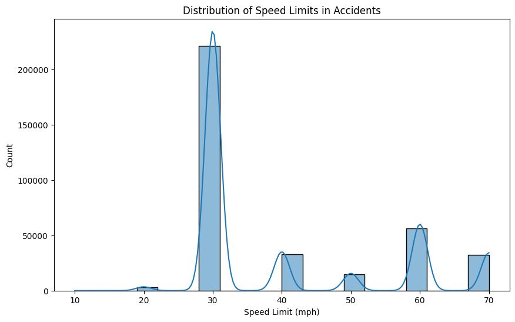

```python
plt.figure(figsize=(10, 6))
sns.histplot(data=df_cleaned, x='Speed_limit', bins=20, kde=True)
plt.title('Distribution of Speed Limits in Accidents')
plt.xlabel('Speed Limit (mph)')
plt.ylabel('Count')
plt.show()
```

The histogram suggests that the majority of accidents occur at lower speed limits, which are typical in more densely populated and trafficked areas. The relatively lower frequency of accidents at very high speed limits might reflect lower traffic volumes or possibly that high-speed accidents are more likely to be fatal and thus result in fewer reported non-fatal accidents.

Bar Chart: Accidents Severity by Day of Week

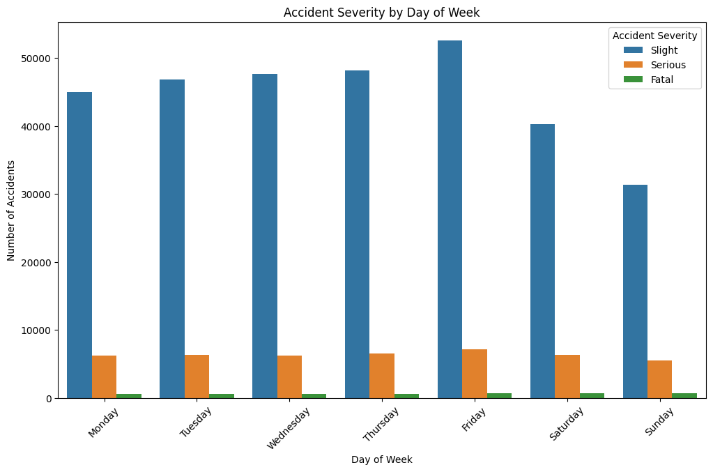

```python
plt.figure(figsize=(12, 7))
sns.countplot(data=df_cleaned, x='Day_of_Week', hue='Accident_Severity', order=['Monday', 'Tuesday', 'Wednesday', 'Thursday', 'Friday', 'Saturday', 'Sunday'])
plt.title('Accident Severity by Day of Week')
plt.xlabel('Day of Week')
plt.ylabel('Number of Accidents')
plt.legend(title='Accident Severity')
plt.xticks(rotation=45)
plt.show()
```

The data suggest that there's a higher incidence of accidents toward the end of the week, particularly on Fridays. Additionally, the prevalence of slight accidents suggests that while road traffic incidents are common, they are less frequently severe or fatal. The lower number of accidents on Sundays could be associated with reduced travel during this day. Overall, these patterns can inform road safety measures and the allocation of traffic management resources.

Scatter Plot: Age of Vehicle vs. Severity Code

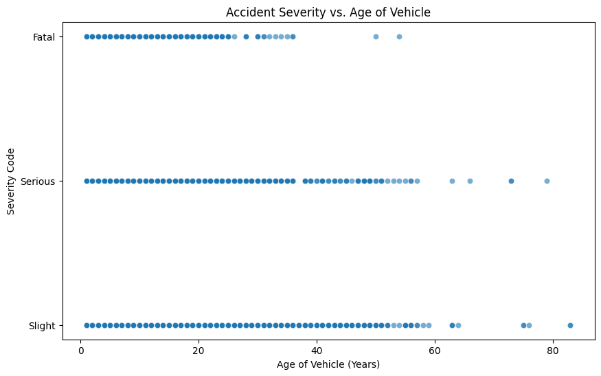

```python
df_cleaned['Severity_Code_Num'] = df_cleaned['Accident_Severity'].map({'Slight': 0, 'Serious': 1, 'Fatal': 2})
plt.figure(figsize=(10, 6))
sns.scatterplot(data=df_cleaned, x='Age_of_Vehicle', y='Severity_Code_Num', alpha=0.6)
plt.title('Accident Severity vs. Age of Vehicle')
plt.xlabel('Age of Vehicle (Years)')
plt.ylabel('Severity Code')
plt.yticks([0, 1, 2], ['Slight', 'Serious', 'Fatal'])
plt.show()
```

The vast majority of accidents involve vehicles that result in slight injuries, as indicated by the dense clustering of data points along the "Slight" severity code. There are fewer serious accidents, and even fewer that are fatal, which is visually represented by the decreasing number of data points for "Serious" and "Fatal" severity codes, respectively.

while this scatter plot provides a distribution of accidents based on vehicle age and severity, it does not strongly suggest that either variable is dependent on the other. The prevalence of accidents with "slight" severity across all vehicle ages indicates that factors other than the vehicle's age might be more influential in the severity of an accident. However, it's important to consider other potential variables not displayed on this plot that could affect accident severity, such as vehicle make and model, maintenance history, and driving conditions.

Box Plot: Speed Limit and Accident Severity

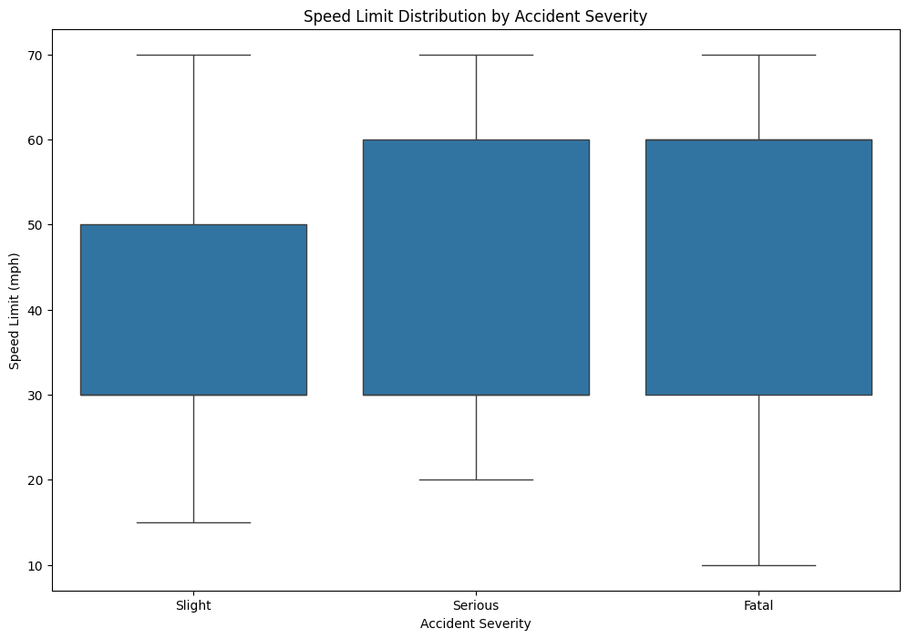

```python
plt.figure(figsize=(12, 8))
sns.boxplot(data=df_cleaned, x='Accident_Severity', y='Speed_limit', order=['Slight', 'Serious', 'Fatal'])
plt.title('Speed Limit Distribution by Accident Severity')
plt.xlabel('Accident Severity')
plt.ylabel('Speed Limit (mph)')
plt.show()
```

Heatmap: Correlation Between Numerical Features

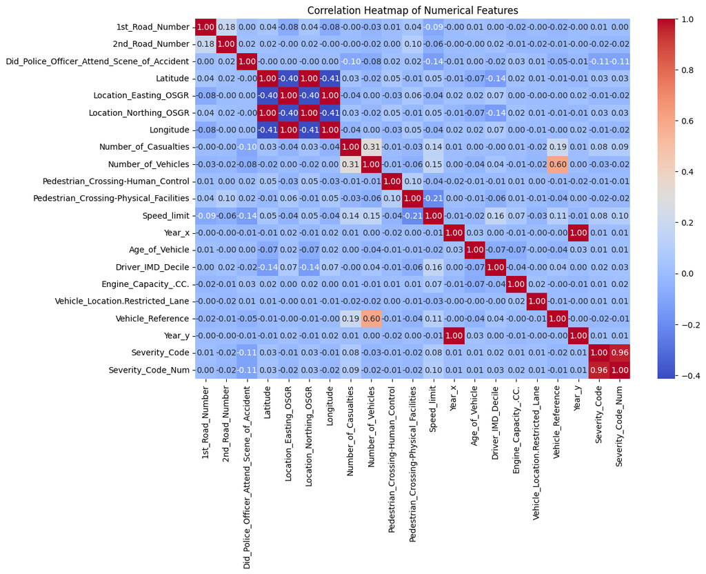

```python
# Calculate correlation matrix
corr = df_cleaned.select_dtypes(include=['float64', 'int64']).corr()

plt.figure(figsize=(12, 8))
sns.heatmap(corr, annot=True, cmap='coolwarm', fmt=".2f")
plt.title('Correlation Heatmap of Numerical Features')
plt.show()
```

The heatmap provides a visual summary of how different variables are related to one another. For a detailed analysis, one should further investigate these relationships, especially those with higher correlation coefficients, as they might reveal significant patterns or inform feature selection in modeling.

### Comparative Analysis

```python
clean_2010_2011 = pd.read_csv('datacleaned_2010_2011.csv')
```

```python
clean_2010_2011.head(3)
```

|  | Accident_Index | 1st_Road_Class | 1st_Road_Number | 2nd_Road_Number | Accident_Severity | Date | Day_of_Week | Did_Police_Officer_Attend_Scene_of_Accident | Junction_Control | Junction_Detail | ... | Skidding_and_Overturning | Towing_and_Articulation | Vehicle_Leaving_Carriageway | Vehicle_Location.Restricted_Lane | Vehicle_Manoeuvre | Vehicle_Reference | Vehicle_Type | Was_Vehicle_Left_Hand_Drive | X1st_Point_of_Impact | Year_y |
| --- | --- | --- | --- | --- | --- | --- | --- | --- | --- | --- | --- | --- | --- | --- | --- | --- | --- | --- | --- | --- | --- |
| 0 | 201001BS70003 | B | 302.0 | 0.0 | Slight | 2010-01-11 | Monday | 1.0 | Give way or uncontrolled | T or staggered junction | ... | NaN | No tow/articulation | Did not leave carriageway | 0.0 | Turning right | 1 | Van / Goods 3.5 tonnes mgw or under | No | Front | 2010 |
| 1 | 201001BS70004 | A | 402.0 | 4204.0 | Slight | 2010-01-11 | Monday | 1.0 | Auto traffic signal | T or staggered junction | ... | NaN | No tow/articulation | Did not leave carriageway | 0.0 | Going ahead other | 1 | Car | No | Front | 2010 |
| 2 | 201001BS70006 | A | 402.0 | 450.0 | Slight | 2010-01-12 | Tuesday | 1.0 | Auto traffic signal | T or staggered junction | ... | NaN | No tow/articulation | Did not leave carriageway | 0.0 | Turning left | 1 | Goods over 3.5t. and under 7.5t | No | Nearside | 2010 |

3 rows × 52 columns

#### Comparative Analysis Over time

```python
severity_comparison = clean_2010_2011.groupby(['Year_y', 'Accident_Severity']).size().unstack(fill_value=0)

severity_comparison
```

| Accident_Severity Year_y | Fatal | Serious | Slight |
| --- | --- | --- | --- |
| 2010 | 2213 | 21785 | 156369 |
| 2011 | 2315 | 22604 | 155697 |

#### Over years

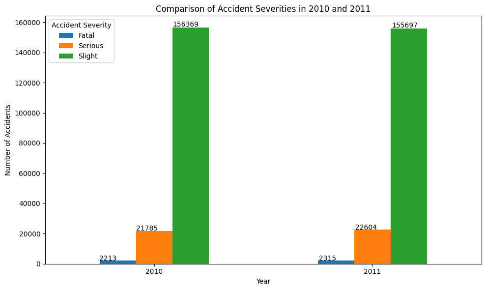

```python
import matplotlib.pyplot as plt

ax = severity_comparison.plot(kind='bar', figsize=(10, 6))
plt.title('Comparison of Accident Severities in 2010 and 2011')
plt.xlabel('Year')
plt.ylabel('Number of Accidents')
plt.xticks(rotation=0)
plt.legend(title='Accident Severity')

for p in ax.patches:
    ax.annotate(str(p.get_height()), (p.get_x() * 1.005, p.get_height() * 1.005))


plt.tight_layout()

plt.show()
```

This comparison over time shows that the numbers are relatively stable with a slight increase from 2213 in 2010 to 2315 in 2011. There is an increase in serious accidents from 21785 in 2010 to 22604 in 2011. Also, the number of slight accidents decreased from 156369 in 2010 to 155697 in 2011. It is interesting that while the number of fatal accidents increased,the number of slight accidents decreased. It may due to several reasons, such as improvements in vehicle safety technology.

#### Over Months

To work more on this part, we create time series plots for each accident type across the months of the year.

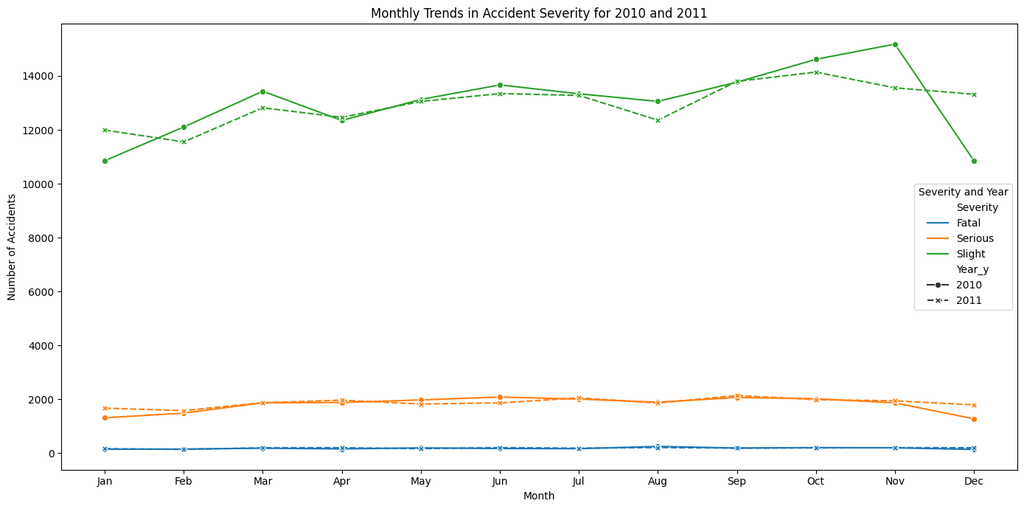

```python
# Correcting date parsing to handle different formats
import seaborn as sns
clean_2010_2011['Date'] = pd.to_datetime(clean_2010_2011['Date'], errors='coerce')

# Extracting the month from the 'Date' column
clean_2010_2011['Month'] = clean_2010_2011['Date'].dt.month

monthly_severity = clean_2010_2011.groupby(['Year_y', 'Month', 'Accident_Severity']).size().unstack(fill_value=0)

monthly_severity = monthly_severity.reset_index()
monthly_severity_melted = monthly_severity.melt(id_vars=['Year_y', 'Month'], var_name='Severity', value_name='Count')

plt.figure(figsize=(14, 7))
sns.lineplot(data=monthly_severity_melted, x='Month', y='Count', hue='Severity', style='Year_y', markers=True)


plt.title('Monthly Trends in Accident Severity for 2010 and 2011')
plt.xlabel('Month')
plt.ylabel('Number of Accidents')
plt.xticks(range(1, 13), ['Jan', 'Feb', 'Mar', 'Apr', 'May', 'Jun', 'Jul', 'Aug', 'Sep', 'Oct', 'Nov', 'Dec'])
plt.legend(title='Severity and Year')

plt.tight_layout()
plt.show()
```

From the plot by months, the number of fatal accidents are evenly distributed in both 2010 and 2011. For serious accidents, the distributions of 2010 and 2011 are similar. In December, the number decreased. The lines for slight accidents fluctuate more than the other two, suggesting more variability in the number of slight accidents from month to month. The general trend of year 2010 and year 2011 seems to follow a similar pattern over the months, increasing first and then decreasing towards the end.

### Comparative Analysis by Road Conditions

By intuition, road condition is one of the key factors for accidents. Thus, in this part, we analyze how different road conditions are related to accident severity and also number f casualties.

```python
relevant_columns = ['Road_Surface_Conditions', 'Accident_Severity', 'Number_of_Casualties']

# Create a subset of the data with the relevant columns
data_by_road_conditions = clean_2010_2011[relevant_columns]

# Group the data by 'Road_Surface_Conditions' and 'Accident_Severity' and count the number of accidents
accidents_by_road_conditions = data_by_road_conditions.groupby(['Road_Surface_Conditions', 'Accident_Severity']).size().unstack(fill_value=0)

mean_casualties_by_road_condition = data_by_road_conditions.groupby('Road_Surface_Conditions')['Number_of_Casualties'].mean()


accidents_by_road_conditions, mean_casualties_by_road_condition
```

```
(Accident_Severity             Fatal  Serious  Slight
 Road_Surface_Conditions
 Data missing or out of range      2       32     353
 Dry                            3117    31899  217308
 Flood over 3cm. deep              4       46     251
 Frost or ice                    136     1217    9995
 Snow                             43      396    4108
 Wet or damp                    1226    10799   80051,
 Road_Surface_Conditions
 Data missing or out of range    1.291990
 Dry                             1.454761
 Flood over 3cm. deep            1.734219
 Frost or ice                    1.499471
 Snow                            1.448208
 Wet or damp                     1.514401
 Name: Number_of_Casualties, dtype: float64)
```

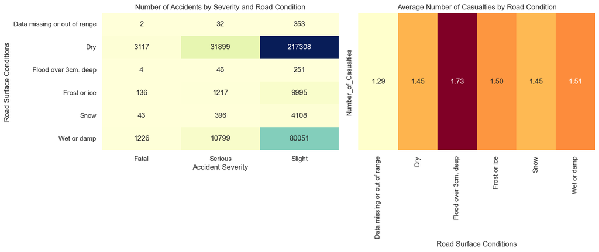

```python
sns.set(style="whitegrid")

# First plot: Number of Accidents by Road Surface Conditions and Severity
plt.figure(figsize=(14, 6))

plt.subplot(1, 2, 1)
sns.heatmap(accidents_by_road_conditions, annot=True, fmt="d", cmap="YlGnBu", cbar=False)
plt.title('Number of Accidents by Severity and Road Condition')
plt.xlabel('Accident Severity')
plt.ylabel('Road Surface Conditions')

# Second plot: Average Number of Casualties by Road Surface Conditions
plt.subplot(1, 2, 2)
sns.heatmap(mean_casualties_by_road_condition.to_frame().T, annot=True, fmt=".2f", cmap="YlOrRd", cbar=False)
plt.title('Average Number of Casualties by Road Condition')
plt.xlabel('Road Surface Conditions')
plt.ylabel('')


plt.tight_layout()
plt.show()
```

Most accidents happened in dry roads, which may because most cars would like to drive in a good weather. There are fewer accidents for extreme conditions like "Flood over 3cm. deep" and "Snow", which may be due to less traffic during such events. However, the average number of casualties for "Flood over 3cm. deep" is the most, indicating accidents happened in this roach condition is more serious than others. In addition, it is notable that many accidents happened in "Wet or damp" roach condition, so drives should be more careful.

### Comparative Analysis by Vehicle Type

To conduct a comparative analysis by vehicle type, we can focus on accident frequency and number of casualties.

```python
accident_frequency = clean_2010_2011['Vehicle_Type'].value_counts()

# Accident Severity by Vehicle Type
severity_counts = clean_2010_2011.groupby(['Vehicle_Type', 'Accident_Severity']).size().unstack(fill_value=0)

accident_frequency_summary = accident_frequency.to_frame(name='Frequency')
severity_summary = severity_counts

accident_frequency_summary.head(), severity_summary.head()
```

```
(                                      Frequency
 Vehicle_Type
 Car                                      278581
 Van / Goods 3.5 tonnes mgw or under       18505
 Motorcycle over 500cc                     12611
 Bus or coach (17 or more pass seats)      11466
 Motorcycle 125cc and under                 9515,
 Accident_Severity                     Fatal  Serious  Slight
 Vehicle_Type
 Agricultural vehicle                     35      170     629
 Bus or coach (17 or more pass seats)    111     1326   10029
 Car                                    2820    29840  245921
 Goods 7.5 tonnes mgw and over           398     1226    5838
 Goods over 3.5t. and under 7.5t          59      361    2331)
```

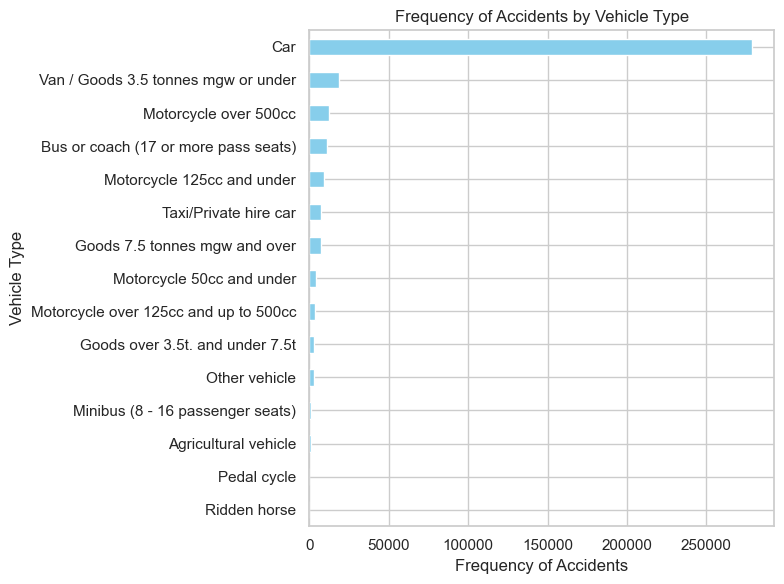

```python
import matplotlib.pyplot as plt

plt.figure(figsize=(8, 6))
accident_frequency.sort_values().plot(kind='barh', color='skyblue')
plt.xlabel('Frequency of Accidents')
plt.ylabel('Vehicle Type')
plt.title('Frequency of Accidents by Vehicle Type')
plt.tight_layout()

plt.show()
```

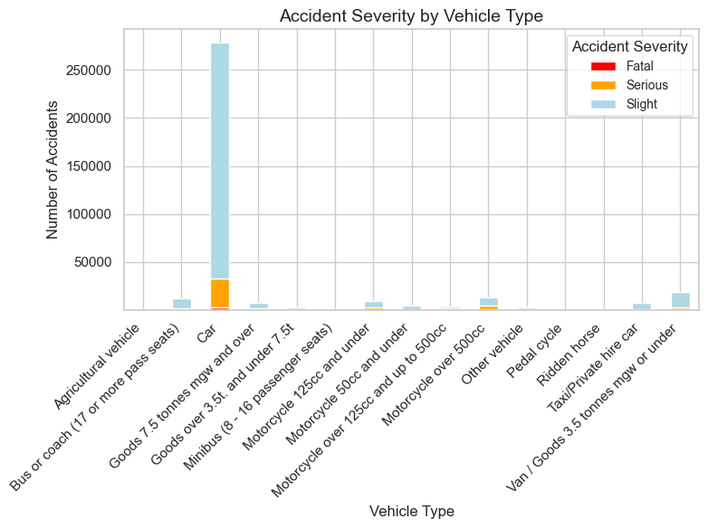

```python
severity_colors = {
    'Slight': 'lightblue',
    'Serious': 'orange',
    'Fatal': 'red'
}

severity_summary.plot(kind='bar',
                      stacked=True,
                      color=[severity_colors.get(x) for x in severity_summary.columns],
                      figsize=(8, 6))

plt.xlabel('Vehicle Type', fontsize=12)
plt.ylabel('Number of Accidents', fontsize=12)
plt.title('Accident Severity by Vehicle Type', fontsize=14)
plt.legend(title='Accident Severity', fontsize=10)
plt.xticks(rotation=45, ha='right')
plt.tight_layout()

plt.show()
```

The comparative analysis reveals the involvement of different vehicle types in road accidents and the relative severity of these incidents. Cars are the most common vehicle on the roads, showing the highest number of accidents. However,it does not have the highest proportion of serious accidents. Motorcycles, particularly those over 500cc, demonstrate a high frequency of accidents relative to their presence on the road. In addition, the serious accidents have a large proportion in the total accidents for motorcycles, which indicates a higher risk factor. Bus and van involve in fewer accidents, but may because fewer numbers on the road. We can still see some portion in serious accidents, likely due to their size and the number of passengers carried.

### Comparative Analysis by Light Conditions

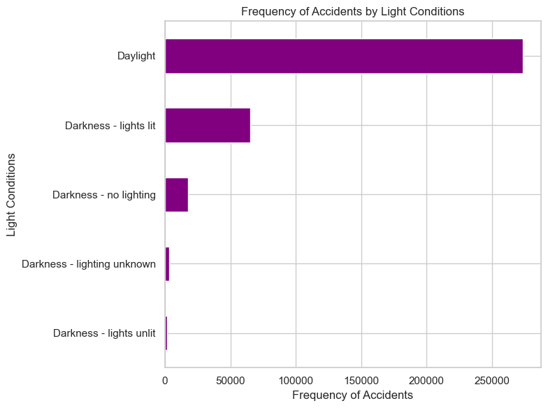

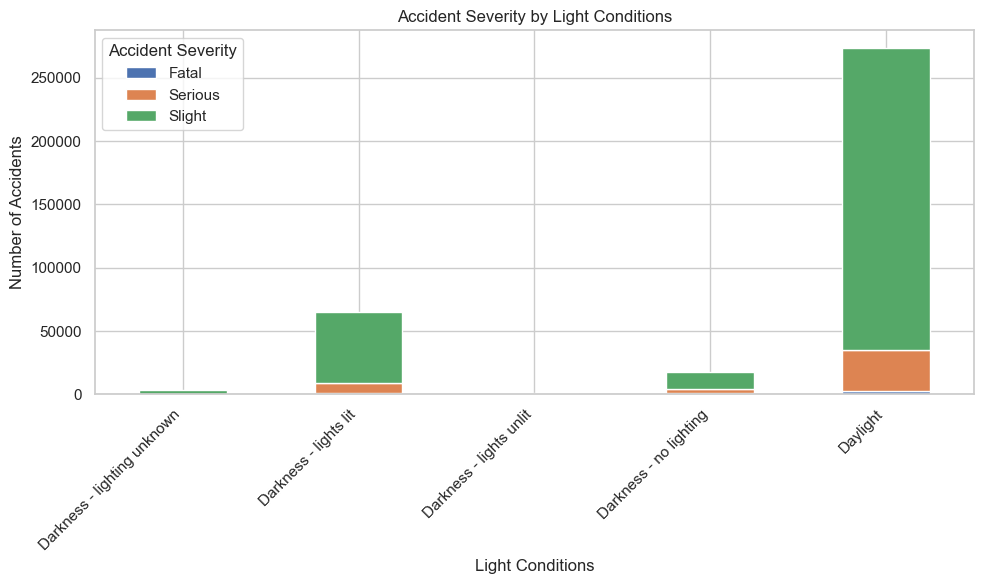

```python
light_conditions_frequency = clean_2010_2011['Light_Conditions'].value_counts()

# Severity of accidents by light conditions
light_conditions_severity = clean_2010_2011.groupby(['Light_Conditions', 'Accident_Severity']).size().unstack(fill_value=0)

# Visualization
# Bar chart for the frequency of accidents by light conditions
plt.figure(figsize=(8, 6))
light_conditions_frequency.sort_values().plot(kind='barh', color='purple')
plt.xlabel('Frequency of Accidents')
plt.ylabel('Light Conditions')
plt.title('Frequency of Accidents by Light Conditions')
plt.tight_layout()
plt.show()

# Stacked bar chart for the severity of accidents by light conditions
light_conditions_severity.plot(kind='bar', stacked=True, figsize=(10, 6))
plt.xlabel('Light Conditions')
plt.ylabel('Number of Accidents')
plt.title('Accident Severity by Light Conditions')
plt.legend(title='Accident Severity')
plt.xticks(rotation=45, ha='right')
plt.tight_layout()
plt.show()
```

The comparative analysis by light conditions shows that most of the accidents happened in day light, suggesting a correlation with the sheer number of vehicles on the road rather than visibility issues. However, it's notable that the darkness with lights lit also contributes to a high proportion, suggesting a risk to drive in the night. It may because the visibility is not good enough. It also suggest that improve lights in the dark may mitigate the risks of accidents.

### Multivariate Analysis

#### Pivot table

```python
# Pivot Table
clean_2010_2011.pivot_table(index='Light_Conditions',
                         columns='Road_Surface_Conditions',
                         values='Number_of_Casualties',
                         aggfunc='mean')
```

| Road_Surface_Conditions Light_Conditions | Data missing or out of range | Dry | Flood over 3cm. deep | Frost or ice | Snow | Wet or damp |
| --- | --- | --- | --- | --- | --- | --- |
| Darkness - lighting unknown | 1.093750 | 1.413466 | 3.200000 | 1.298013 | 1.533333 | 1.505249 |
| Darkness - lights lit | 1.225806 | 1.452336 | 1.956522 | 1.501393 | 1.427488 | 1.480758 |
| Darkness - lights unlit | NaN | 1.402685 | 3.000000 | 1.597403 | 1.240000 | 1.492537 |
| Darkness - no lighting | 2.285714 | 1.687295 | 1.786667 | 1.818080 | 1.605505 | 1.660904 |
| Daylight | 1.304196 | 1.447189 | 1.595376 | 1.418986 | 1.425926 | 1.510260 |

The pivot table is to present a multivariate analysis exploring the interaction between light conditions during accidents and the condition of the road surface. The light conditions vary from full daylight to various forms of darkness. The road surface conditions range from dry to severe with flooding, frost or ice, snow, and wet or damp conditions.The value in each cell is filled with the number of casualties.

Accidents occurring in darkness with no lighting tend to have higher values across different road surface conditions, like "dry", "Frost or ice", "snow", and "wet or damp". The road condition of flood over 3cm deep also shows high values, indicating a significant risk factor. It makes sense that it's harder to drive on flood.

#### Cross-tabulation

We also perform a cross-tabulation with the variables Light_Conditions, Road_Surface_Conditions, and Weather_Conditions.

```python
three_way_crosstab = pd.crosstab(index=[clean_2010_2011['Light_Conditions'], clean_2010_2011['Weather_Conditions']],
                                 columns=clean_2010_2011['Road_Surface_Conditions'],
                                 margins=True,
                                 margins_name="Total")

three_way_crosstab
```

| Light_Conditions | Road_Surface_Conditions Weather_Conditions | Data missing or out of range | Dry | Flood over 3cm. deep | Frost or ice | Snow | Wet or damp | Total |
| --- | --- | --- | --- | --- | --- | --- | --- | --- |
| Darkness - lighting unknown | Fine + high winds | 0 | 21 | 0 | 4 | 0 | 9 | 34 |
|  | Fine no high winds | 0 | 1606 | 0 | 68 | 11 | 308 | 1993 |
|  | Fog or mist | 0 | 1 | 0 | 11 | 0 | 32 | 44 |
|  | Other | 3 | 13 | 0 | 32 | 2 | 35 | 85 |
|  | Raining + high winds | 0 | 1 | 2 | 2 | 0 | 33 | 38 |
|  | Raining no high winds | 0 | 1 | 3 | 3 | 0 | 285 | 292 |
|  | Snowing + high winds | 0 | 0 | 0 | 1 | 10 | 0 | 11 |
|  | Snowing no high winds | 0 | 1 | 0 | 5 | 30 | 4 | 40 |
|  | Unknown | 29 | 569 | 0 | 25 | 7 | 56 | 686 |
| Darkness - lights lit | Data missing or out of range | 0 | 1 | 0 | 0 | 0 | 0 | 1 |
|  | Fine + high winds | 0 | 414 | 1 | 24 | 3 | 328 | 770 |
|  | Fine no high winds | 10 | 35046 | 9 | 1317 | 170 | 11170 | 47722 |
|  | Fog or mist | 0 | 78 | 0 | 84 | 5 | 345 | 512 |
|  | Other | 10 | 249 | 3 | 651 | 98 | 1275 | 2286 |
|  | Raining + high winds | 0 | 4 | 16 | 10 | 2 | 1173 | 1205 |
|  | Raining no high winds | 0 | 38 | 14 | 99 | 11 | 10319 | 10481 |
|  | Snowing + high winds | 0 | 0 | 0 | 13 | 61 | 21 | 95 |
|  | Snowing no high winds | 0 | 4 | 3 | 285 | 694 | 201 | 1187 |
|  | Unknown | 42 | 493 | 0 | 30 | 11 | 191 | 767 |
| Darkness - lights unlit | Fine + high winds | 0 | 16 | 0 | 5 | 0 | 7 | 28 |
|  | Fine no high winds | 0 | 707 | 2 | 37 | 6 | 226 | 978 |
|  | Fog or mist | 0 | 2 | 0 | 1 | 0 | 10 | 13 |
|  | Other | 0 | 7 | 0 | 20 | 1 | 34 | 62 |
|  | Raining + high winds | 0 | 0 | 0 | 0 | 0 | 38 | 38 |
|  | Raining no high winds | 0 | 1 | 0 | 1 | 0 | 211 | 213 |
|  | Snowing + high winds | 0 | 0 | 0 | 2 | 3 | 0 | 5 |
|  | Snowing no high winds | 0 | 0 | 0 | 11 | 15 | 0 | 26 |
|  | Unknown | 0 | 12 | 0 | 0 | 0 | 10 | 22 |
| Darkness - no lighting | Data missing or out of range | 0 | 4 | 0 | 2 | 0 | 1 | 7 |
|  | Fine + high winds | 0 | 150 | 0 | 27 | 3 | 140 | 320 |
|  | Fine no high winds | 0 | 7273 | 8 | 960 | 80 | 3660 | 11981 |
|  | Fog or mist | 0 | 28 | 1 | 95 | 4 | 305 | 433 |
|  | Other | 1 | 68 | 3 | 397 | 38 | 324 | 831 |
|  | Raining + high winds | 0 | 2 | 14 | 5 | 0 | 450 | 471 |
|  | Raining no high winds | 0 | 10 | 48 | 82 | 4 | 2511 | 2655 |
|  | Snowing + high winds | 0 | 0 | 0 | 23 | 83 | 11 | 117 |
|  | Snowing no high winds | 0 | 1 | 1 | 178 | 328 | 61 | 569 |
|  | Unknown | 6 | 91 | 0 | 12 | 5 | 57 | 171 |
| Daylight | Data missing or out of range | 0 | 55 | 0 | 1 | 0 | 3 | 59 |
|  | Fine + high winds | 2 | 2176 | 5 | 50 | 16 | 891 | 3140 |
|  | Fine no high winds | 39 | 198785 | 30 | 4159 | 706 | 26502 | 230221 |
|  | Fog or mist | 0 | 166 | 0 | 160 | 14 | 628 | 968 |
|  | Other | 15 | 859 | 5 | 1505 | 227 | 2533 | 5144 |
|  | Raining + high winds | 0 | 28 | 25 | 6 | 1 | 2005 | 2065 |
|  | Raining no high winds | 0 | 226 | 103 | 175 | 55 | 24788 | 25347 |
|  | Snowing + high winds | 0 | 0 | 1 | 58 | 193 | 35 | 287 |
|  | Snowing no high winds | 0 | 11 | 1 | 633 | 1626 | 356 | 2627 |
|  | Unknown | 230 | 3106 | 3 | 79 | 24 | 494 | 3936 |
| Total |  | 387 | 252324 | 301 | 11348 | 4547 | 92076 | 360983 |

From this cross-tabulation, most accidents occur in dry conditions during daylight with fine weather and no high winds. This could be attributed to higher traffic volumes, as people are commuting to work, school, or other activities. Furthermore, drivers may be less vigilant during better conditions, leading to complacency on the road. Darkness with lights lit is the second most common condition for accidents under the same weather settings. It may because artificial lights are not visible enough. Drivers' ability to judge distances could be compromised.

Moreover, there is a significant number of accidents in wet or damp conditions occur in darkness with lights lit when the weather is fine and also when it's raining without high winds. Wet roads reduce tire traction, increasing the likelihood of skidding. The combination of wet surfaces with the decreased visibility of night-time driving leads to a challenging environment for drivers. Even with lights on, the reflection of light on wet surfaces may cause glare and further reduce visibility.

### Synthesis

Our research question focused on "What are relationships between different factors and the accident severity?" How to possibly avoid accidents in all levels, especially serious and fetal accidents?

Overall, we can concluded that:

In sort, objective factors such as speed limit, the time some one drives can affect the severity of accidents. However, it is also important for drivers to be careful all the time and do not lose concentration during conditions seems safer.

The whole analysis is only possible while combing the vehicle information data and the accident data, since our study involves the accident severity with vehicle age, vehicle type and etc. With only one dataset, those factors would not be studied. By combining the information of cars involves in accidents with the accident information, it provides us whole pictures to study road accidents, and possibly prevent them.

#### Reflection

For fitting model, since our response is accident severity, which shown as "Slight", "Serious" and "Fetal" in the table and are unable to create a model directly. Thus we used dummy variables to mark slight as 0 and serious or fetal as 1 and fitted the model.

The process of choosing the best type of plots also involves thinking. We considered type of data, how much information we would like to present, and what is the most clear for demonstrated the information.

Our study may not be generalized enough to show the whole picture. For future studies, we can involves in more years of data or similar data from other sources to validates our findings.

In addition, data are highly imbalanced. For example, we notice that there are more accidents during daytime, however, it might be due to more vehicles during daytime. For further analysis, we could oversampling the minority classes or undersampling the majority classes. We could also weight each classes based on their frequencies.

All these changes can help enhance the robustness of our findings.